# Time Series 01: Why Metadata Are Important: How to Work with Metadata in Text & EML Format

This tutorial covers what metadata are, and why we need to work with metadata. It covers the 3 most common metadata formats: text file format, web page format and Ecological Metadata Language (EML).

**R Skill Level:** Introduction - you’ve got the basics of R down and understand the general structure of tabular data.

## Learning Objectives

After completing this tutorial, you will be able to:

- Import a .csv file and examine the structure of the related R object.
- Use a metadata file to better understand the content of a dataset.
- Explain the importance of including metadata details in your R script.
- Describe what an EML file is.

## Things You’ll Need To Complete This Tutorial

You will need the most current version of R and, preferably, RStudio loaded on your computer to complete this tutorial.

### Install R Packages

When presented in a workshop, the `EML` package will be presented as a demonstration!

If completing EML portion of tutorial on your own, you must install `EML` directly from GitHub (the package is in development and is not yet on CRAN). You will need to install `devtools` to do this.

- **ggmap:** `install.packages("ggmap")`
- **tmaptools:** `install.packages("tmaptools")`
- **devtools:** `install.packages("devtools");library(devtools)`
- **EML:** **must be installed AFTER `devtools` is loaded in R. `install_github("ropensci/EML", build=FALSE, dependencies=c("DEPENDS", "IMPORTS"))`

### [NEON Teaching Data Subset: Meteorological Data for Harvard Forest](https://ndownloader.figshare.com/files/3701572)

The data used in this lesson were collected at the [National Ecological Observatory Network’s](https://www.neonscience.org/) [Harvard Forest field site](https://www.neonscience.org/field-sites/field-sites-map/HARV). These data are proxy data for what will be available for 30 years on the [NEON data portal](http://data.neonscience.org/) for the Harvard Forest and other field sites located across the United States.

[Download Dataset](https://ndownloader.figshare.com/files/3701572)

**Set Working Directory:** This lesson assumes that you have set your working directory to the location of the downloaded and unzipped data subsets.

[An overview of setting the working directory in R can be found here.](https://www.neonscience.org/set-working-directory-r)

**R Script & Challenge Code:** NEON data lessons often contain challenges that reinforce learned skills. If available, the code for challenge solutions is found in the downloadable R script of the entire lesson, available in the footer of each lesson page.

## Understand Our Data

In order to work with any data, we need to understand three things about the data:

- Structure
- Format
- Processing methods

If the data are collected by other people and organizations, we might also need further information about:

- What metrics are included in the dataset
- The units those metrics were stored in
- Explanation of where the metrics are stored in the data and what they are “called” (e.g. what are the column names in a spreadsheet)
- The time range that it covers
- The spatial extent that the data covers

The above information, and more are stored in **metadata** - data about the data. Metadata is information that describes a dataset and is integral to working with external data (data that we did not collect ourselves).

## Metadata Formats

Metadata come in different formats. We will discuss three of those in this tutorial:

- **Ecological Metadata Language (EML):** A standardized metadata format stored in `xml` format which is machine readable. Metadata has some standards however it’s common to encounter metadata stored differently in EML files created by different organizations.
- **Text file:** Sometimes metadata files can be found in text files that are either downloaded with a data product OR that are available separately for the data.
- **Directly on a website (HTML / XML):** Sometimes data are documented directly in text format, on a web page.

**Data Tip:** When you find metadata for a dataset that you are working with, immediately **DOWNLOAD AND SAVE IT** to the directory on your computer where you saved the data. It is also a good idea to document the URL where you found the metadata and data in a “readme” text file!

## Metadata Stored on a Web Page

The metadata for the data that we are working with for the Harvard Forest field site are stored in both `EML` format and on a web page. Let’s explore the web page first.

- [View Harvard Forest Fisher Tower webpage.](https://harvardforest.fas.harvard.edu/harvard-forest-data-archive)

Let’s begin by visiting that page above. At the top of the page, there is a list of data available for Harvard Forest. NOTE: **hf001-06: daily (metric) since 2001 (preview)** is the data that we used in the [previous tutorial.](https://www.neonscience.org/dc-brief-tabular-time-series-qplot-r)

Scroll down to the **Overview** section on the website. Take note of the information provided in that section and answer the questions in the Challenge below.

### Challenge: Explore Metadata

Explore the metadata stored on the Harvard Forest LTER web page. Answer the following questions.

1. What is the time span of the data available for this site?
2. You have some questions about these data. Who is the lead investigator / who do you contact for more information? And how do you contact them?
3. Where is this field site located? How is the site location information stored in the metadata? Is there any information that may be useful to you viewing the location? HINT: What if you were not familiar with Harvard as a site / from another country, etc?
4. Field Site Information: What is the elevation for the site? What is the dominant vegetation cover for the site? HINT: Is dominant vegetation easy to find in the metadata?
5. How is snow dealt with in the precipitation data?
6. Are there some metadata attributes that might be useful to access in a script in R or `Python` rather than viewed on a web page? HINT: Can you answer all of the questions above from the information provided on this website? Is there additional information that you might want to find on the page?

### View Metadata For Metrics of Interest

For this tutorial series, we are interested in the drivers of plant phenology - specifically air and soil temperature, precipitation and photosynthetically active radiation (PAR). Let’s look for descriptions of these variables in the metadata and determine several key attributes that we will need prior to working with the data.

### Challenge: Metrics of Interest Metadata

View the metadata at the URL above. Answer the following questions about the Harvard Forest LTER data - **hf001-10: 15-minute (metric) since 2005**:

1. What is the column heading name where each variable (air temperature, soil temperature, precipitation and PAR) is stored?
2. What are the units that each variable are stored in?
3. What is the frequency of measurement collected for each and how are noData values stored?
4. Where is the date information stored (in what field) and what timezone are the dates stored in?

### Why Metadata on a Web Page Is Not Ideal

It is nice to have a web page that displays metadata information, however accessing metadata on a web page is difficult:

- If the web page URL changes or the site goes down, the information is lost.
- It’s also more challenging to access metadata in text format on a web page programatically - like using R as an interface - which we often want to do when working with larger datasets.

A machine readable metadata file is better - especially when we are working with large data and we want to automate and carefully document workflows. The Ecological Metadata Language (EML) is one machine readable metadata format.

## Ecological Metadata Language (EML)

While much of the documentation that we need to work with at the Harvard Forest field site is available directly on the [Harvard Forest Data Archive page](https://harvardforest.fas.harvard.edu/harvard-forest-data-archive), the website also offers metadata in `EML` format.

## Introduction to EML

The Ecological Metadata Language (EML) is a data specification developed specifically to document ecological data. An EML file is created using a `XML` based format. This means that content is embedded within hierarchical tags. For example, the title of a dataset might be embedded in a `<title>` tag as follows:

`<title>Fisher Meteorological Station at Harvard Forest since 2001</title>`

Similarly, the creator of a dataset is also be found in a hierarchical tag structure.

```
<creator>
  <individualName>
    <givenName>Emery</givenName>
    <surName>Boose</surName>
  </individualName>
</creator>
```

The `EML` package for R is designed to read and allow users to work with EML formatted metadata. In this tutorial, we demonstrate how we can use EML in an automated workflow.

NOTE: The `EML` package is still being developed, therefore we will not explicitly teach all details of how to use it. Instead, we will provide an example of how you can access EML files programmatically and background information so that you can further explore EML and the `EML` package if you need to work with it further.

## EML Terminology

Let’s first discuss some basic EML terminology. In the context of EML, each EML file documents a **dataset**. This **dataset** may consist of one or more files that contain the data in **data tables**. In the case of our tabular meteorology data, the structure of our EML file includes:

1. The **dataset**. A dataset may contain one or more data tables associated with it that may contain different types of related information. For this Harvard Forest meteorological data, the data tables contain tower measurements including precipitation and temperature, that are aggregated at various time intervals (15 minute, daily, etc) and that date back to 2001.
2. The **data tables**. Data tables refer to the actual data that make up the dataset. For the Harvard Forest data, each data table contains a suite of meteorological metrics, including precipitation and temperature (and associated quality flags), that are aggregated at a particular time interval (e.g. one data table contains monthly average data, another contains 15 minute averaged data, etc).

## Work With EML in R

To begin, we will load the `EML` package directly from ROpenSci’s Git repository.

```r
# install R EML tool
# load devtools (if you need to install "EML")
#library("devtools")
# IF YOU HAVE NOT DONE SO ALREADY: install EML from github -- package in
# development; not on CRAN
#install_github("ropensci/EML", build=FALSE, dependencies=c("DEPENDS", "IMPORTS"))

# load ROpenSci EML package
library(EML)
# load ggmap for mapping
library(ggmap)
# load tmaptools for mapping
library(tmaptools)
```

Note that because this EML file is large, it takes a few seconds for the file to load.

```r
# data location
# http://harvardforest.fas.harvard.edu:8080/exist/apps/datasets/showData.html?id=hf001
# table 4 http://harvardforest.fas.harvard.edu/data/p00/hf001/hf001-04-monthly-m.csv

# import EML from Harvard Forest Met Data
# note, for this particular tutorial, we will work with an abridged version of the file
# that you can access directly on the harvard forest website. (see comment below)
eml_HARV <- read_eml("https://harvardforest1.fas.harvard.edu/sites/harvardforest.fas.harvard.edu/files/data/eml/hf001.xml")

# import a truncated version of the eml file for quicker demonstration
# eml_HARV <- read_eml("http://neonscience.github.io/NEON-R-Tabular-Time-Series/hf001-revised.xml")

# view size of object
object.size(eml_HARV)
```

```
## 1299552 bytes
```

```r
# view the object class
class(eml_HARV)
```

```
## [1] "emld" "list"
```

# Explore Metadata Attributes

We can begin to explore the contents of our EML file and associated data that it describes. Let’s start at the **dataset** level. We can use `slots` to view the contact information for the dataset and a description of the methods.

```r
# view the contact name listed in the file

eml_HARV$dataset$creator
```

```
## $individualName
## $individualName$givenName
## [1] "Emery"
##
## $individualName$surName
## [1] "Boose"
```

```r
# view information about the methods used to collect the data as described in EML
eml_HARV$dataset$methods
```

```
## $methodStep
## $methodStep$description
## $methodStep$description$section
## $methodStep$description$section[[1]]
## [1] "<title>Observation periods</title><para>15-minute: 15 minutes, ending with given time. Hourly: 1 hour, ending with given time. Daily: 1 day, midnight to midnight. All times are Eastern Standard Time.</para>"
##
## $methodStep$description$section[[2]]
## [1] "<title>Instruments</title><para>Air temperature and relative humidity: Vaisala HMP45C (2.2m above ground). Precipitation: Met One 385 heated rain gage (top of gage 1.6m above ground). Global solar radiation: Licor LI200X pyranometer (2.7m above ground). PAR radiation: Licor LI190SB quantum s…
##
## $methodStep$description$section[[3]]
## [1] "<title>Instrument and flag notes</title><para>Air temperature. Daily air temperature is estimated from other stations as needed to complete record.</para><para>Precipitation. Daily precipitation is estimated from other stations as needed to complete record. Delayed melting of snow and ice (c…
```

## Identify & Map Data Location

NOTE: If this were a rectangular extent, we’d want the bounding box not just the point. This is important if the data in raster, HDF5, or a similar format. We need the extent to properly geolocate and process the data.

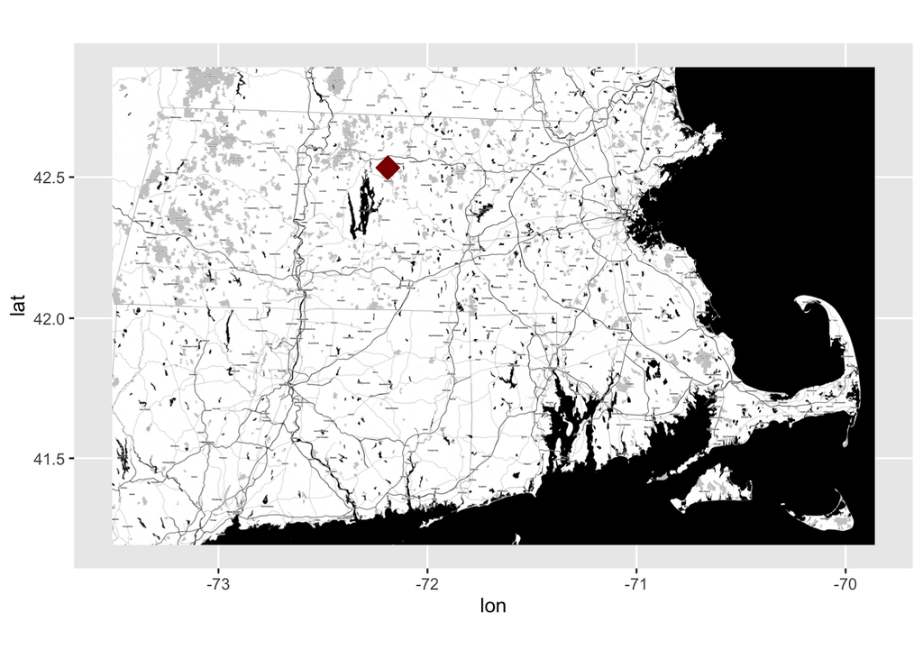

Map of Massachusetts, U.S.A., showing location of Harvard Forest

```r
# grab x coordinate from the coverage information
XCoord <- eml_HARV$dataset$coverage$geographicCoverage$boundingCoordinates$westBoundingCoordinate[[1]]
# grab y coordinate from the coverage information
YCoord <- eml_HARV$dataset$coverage$geographicCoverage$boundingCoordinates$northBoundingCoordinate[[1]]
# make a map and add the xy coordinates to it
ggmap(get_stamenmap(rbind(as.numeric(paste(geocode_OSM("Massachusetts")$bbox))), zoom = 11, maptype=c("toner")), extent=TRUE) + geom_point(aes(x=as.numeric(XCoord),y=as.numeric(YCoord)),
             color="darkred", size=6, pch=18)
```

- Learn more about `ggmap`: [A nice cheatsheet created by NCEAS](https://www.nceas.ucsb.edu/~frazier/RSpatialGuides/ggmap/ggmapCheatsheet.pdf)

The above example, demonstrated how we can extract information from an `EML` document and use it programatically in R! This is just the beginning of what we can do!

## Metadata For Your Own Data

Now, imagine that you are working with someone else’s data and you don’t have a metadata file associated with it? How do you know what units the data were in? How the data were collected? The location that the data covers? It is equally important to create metadata for your own data, to make your data more efficiently “shareable”.